# STAT 301

**Group 19** · **Name: Medhansh Choubey** · **Student ID: 50146505**

## Section 0: TA Feedback

**Stage 1 Score: 29.5/30**

**TA Feedback:**

- Missing comments in code

**Revisions Made:**

- Added comprehensive code comments throughout all code cells (highlighted with `# REVISED:`)

```r
# REVISED: Added descriptive comments for each library
library(tidyverse)  # Data manipulation and visualization
library(readxl)     # Reading Excel files
library(broom)      # Tidying model outputs
library(cowplot)    # Publication-ready plots
library(repr)       # Setting plot dimensions in Jupyter
library(car)        # NEW: Variance Inflation Factor for multicollinearity check
```

```r
setwd("/Users/medhanshchoubey/gallstone-logistic-model-1/gallstone-risk-inference")

# Verify working directory is correct
print(paste("Working directory:", getwd()))

# Check if data file exists
print(paste("Files in gallstone_data:", paste(list.files("gallstone_data"), collapse=", ")))
```

```
[1] "Working directory: /Users/medhanshchoubey/gallstone-logistic-model-1/gallstone-risk-inference"
[1] "Files in gallstone_data: dataset-uci.xlsx"
```

## Section 1: Data Description

```r
# REVISED: Added comments explaining each inspection step

# Load the raw dataset from Excel file
gallstone_raw <- read_excel("gallstone_data/dataset-uci.xlsx")

# Check dimensions: 319 rows (patients) × 39 columns (variables)
dim(gallstone_raw)

# Display all variable names to understand data structure
colnames(gallstone_raw)

# Preview first 3 rows to see data format
head(gallstone_raw, 3)

# Verify dataset size
nrow(gallstone_raw)  # Number of patients
ncol(gallstone_raw)  # Number of variables

# Check for missing values across entire dataset
sum(is.na(gallstone_raw))  # Total missing values

# Check missing values by column
colSums(is.na(gallstone_raw))  # No missing values found (all 0s)
```

1. 319

2. 39

1. 'Gallstone Status'

2. 'Age'

3. 'Gender'

4. 'Comorbidity'

5. 'Coronary Artery Disease (CAD)'

6. 'Hypothyroidism'

7. 'Hyperlipidemia'

8. 'Diabetes Mellitus (DM)'

9. 'Height'

10. 'Weight'

11. 'Body Mass Index (BMI)'

12. 'Total Body Water (TBW)'

13. 'Extracellular Water (ECW)'

14. 'Intracellular Water (ICW)'

15. 'Extracellular Fluid/Total Body Water (ECF/TBW)'

16. 'Total Body Fat Ratio (TBFR) (%)'

17. 'Lean Mass (LM) (%)'

18. 'Body Protein Content (Protein) (%)'

19. 'Visceral Fat Rating (VFR)'

20. 'Bone Mass (BM)'

21. 'Muscle Mass (MM)'

22. 'Obesity (%)'

23. 'Total Fat Content (TFC)'

24. 'Visceral Fat Area (VFA)'

25. 'Visceral Muscle Area (VMA) (Kg)'

26. 'Hepatic Fat Accumulation (HFA)'

27. 'Glucose'

28. 'Total Cholesterol (TC)'

29. 'Low Density Lipoprotein (LDL)'

30. 'High Density Lipoprotein (HDL)'

31. 'Triglyceride'

32. 'Aspartat Aminotransferaz (AST)'

33. 'Alanin Aminotransferaz (ALT)'

34. 'Alkaline Phosphatase (ALP)'

35. 'Creatinine'

36. 'Glomerular Filtration Rate (GFR)'

37. 'C-Reactive Protein (CRP)'

38. 'Hemoglobin (HGB)'

39. 'Vitamin D'

A tibble: 3 × 39

| Gallstone Status <dbl> | Age <dbl> | Gender <dbl> | Comorbidity <dbl> | Coronary Artery Disease (CAD) <dbl> | Hypothyroidism <dbl> | Hyperlipidemia <dbl> | Diabetes Mellitus (DM) <dbl> | Height <dbl> | Weight <dbl> | ⋯ | High Density Lipoprotein (HDL) <dbl> | Triglyceride <dbl> | Aspartat Aminotransferaz (AST) <dbl> | Alanin Aminotransferaz (ALT) <dbl> | Alkaline Phosphatase (ALP) <dbl> | Creatinine <dbl> | Glomerular Filtration Rate (GFR) <dbl> | C-Reactive Protein (CRP) <dbl> | Hemoglobin (HGB) <dbl> | Vitamin D <dbl> |
| --- | --- | --- | --- | --- | --- | --- | --- | --- | --- | --- | --- | --- | --- | --- | --- | --- | --- | --- | --- | --- |
| 0 | 50 | 0 | 0 | 0 | 0 | 0 | 0 | 185 | 92.8 | ⋯ | 40 | 134 | 20 | 22 | 87 | 0.82 | 112.47 | 0 | 16.0 | 33.0 |
| 0 | 47 | 0 | 1 | 0 | 0 | 0 | 0 | 176 | 94.5 | ⋯ | 43 | 103 | 14 | 13 | 46 | 0.87 | 107.10 | 0 | 14.4 | 25.0 |
| 0 | 61 | 0 | 0 | 0 | 0 | 0 | 0 | 171 | 91.1 | ⋯ | 43 | 69 | 18 | 14 | 66 | 1.25 | 65.51 | 0 | 16.2 | 30.2 |

319

39

0

**Gallstone Status**

0

**Age**

0

**Gender**

0

**Comorbidity**

0

**Coronary Artery Disease (CAD)**

0

**Hypothyroidism**

0

**Hyperlipidemia**

0

**Diabetes Mellitus (DM)**

0

**Height**

0

**Weight**

0

**Body Mass Index (BMI)**

0

**Total Body Water (TBW)**

0

**Extracellular Water (ECW)**

0

**Intracellular Water (ICW)**

0

**Extracellular Fluid/Total Body Water (ECF/TBW)**

0

**Total Body Fat Ratio (TBFR) (%)**

0

**Lean Mass (LM) (%)**

0

**Body Protein Content (Protein) (%)**

0

**Visceral Fat Rating (VFR)**

0

**Bone Mass (BM)**

0

**Muscle Mass (MM)**

0

**Obesity (%)**

0

**Total Fat Content (TFC)**

0

**Visceral Fat Area (VFA)**

0

**Visceral Muscle Area (VMA) (Kg)**

0

**Hepatic Fat Accumulation (HFA)**

0

**Glucose**

0

**Total Cholesterol (TC)**

0

**Low Density Lipoprotein (LDL)**

0

**High Density Lipoprotein (HDL)**

0

**Triglyceride**

0

**Aspartat Aminotransferaz (AST)**

0

**Alanin Aminotransferaz (ALT)**

0

**Alkaline Phosphatase (ALP)**

0

**Creatinine**

0

**Glomerular Filtration Rate (GFR)**

0

**C-Reactive Protein (CRP)**

0

**Hemoglobin (HGB)**

0

**Vitamin D**

0

### Dataset Summary

**Number of observations:** 319

**Number of variables:** 39

**Variable Names and Types:**

| Variable | Type | Description |
| --- | --- | --- |
| Gallstone Status | Binary (factor; 0=Absent, 1=Present) | Response |
| Age | Continuous (numeric) | Years |
| Gender | Binary (factor; 0=Female, 1=Male) | Sex |
| Height | Continuous (numeric) | cm |
| Weight | Continuous (numeric) | kg |
| Body Mass Index (BMI) | Continuous (numeric) | kg/m² |
| Total Body Water (TBW) | Continuous (numeric) | Body water |
| Extracellular Water (ECW) | Continuous (numeric) | Compartment |
| Intracellular Water (ICW) | Continuous (numeric) | Compartment |
| Extracellular Fluid / TBW (ECF/TBW) | Continuous (numeric) | Ratio |
| Body Fat % (BF%) | Continuous (numeric) | % |
| Lean Mass | Continuous (numeric) | kg |
| Protein % | Continuous (numeric) | % |
| Visceral Fat Rating (VFR) | Ordinal (integer scale) | Device rating |
| Bone Mass | Continuous (numeric) | kg |
| Muscle Mass (MM) | Continuous (numeric) | kg |
| Total Fat Content (TFC) | Continuous (numeric) | Fat mass |
| Visceral Fat Area (VFA) | Continuous (numeric) | cm² |
| Hepatic Fat Accumulation (HFA) | Ordinal (0–4) | Liver fat grade |
| Comorbidity | Ordinal (0–3) | Comorbidity grade |
| Glucose | Continuous (numeric) | mg/dL |
| Triglyceride | Continuous (numeric) | mg/dL |
| Creatinine | Continuous (numeric) | mg/dL |
| Total Cholesterol (TC) | Continuous (numeric) | mg/dL |
| LDL | Continuous (numeric) | mg/dL |
| HDL | Continuous (numeric) | mg/dL |
| AST | Continuous (numeric) | U/L |
| ALT | Continuous (numeric) | U/L |
| ALP | Continuous (numeric) | U/L |
| CRP | Continuous (numeric) | mg/L |
| Estimated GFR (GFR) | Continuous (numeric) | Kidney function |
| CAD | Binary (factor; 0/1) | Coronary artery disease |
| Hypothyroidism | Binary (factor; 0/1) | Thyroid disorder |
| Hyperlipidemia | Binary (factor; 0/1) | Dyslipidemia |
| DM | Binary (factor; 0/1) | Diabetes |
| Hemoglobin (HGB) | Continuous (numeric) | g/dL |
| Vitamin D | Continuous (numeric) | ng/mL |

**Source and Information:**

This dataset contains clinical and metabolic measurements from patients screened for gallstone disease. The data includes demographic information, anthropometric measurements, body composition analysis, metabolic markers, and liver function tests. Each observation represents one patient.

**Source:** UCI Machine Learning Repository - Gallstone Disease Dataset. Available at: https://archive.ics.uci.edu/dataset/1150/gallstone-1

### Pre-selection of Variables

**Variables to DROP:**

- Height and Weight: Redundant information since BMI is already calculated
- Total Body Water, ECW, ICW, ECF/TBW: Multiple body water measurements provide redundant information
- Bone Mass, Muscle Mass, Lean Mass, Body Protein Content: Body composition details not directly related to gallstone formation
- AST, ALT, ALP, Creatinine, GFR, CRP, Hemoglobin: Secondary clinical markers; focusing on primary metabolic risk factors
- Comorbidity, CAD, Hypothyroidism, Hyperlipidemia: Multiple disease indicators; keeping only Diabetes as key metabolic disease
- Vitamin D: Limited direct connection to gallstone pathophysiology
- VFR, Obesity %: Redundant with Visceral Fat Area and BMI

**Variables to KEEP:**

- Gallstone Status: Response variable
- Age, Gender: Key demographic predictors
- BMI: Primary obesity measure
- Glucose, Diabetes: Glucose metabolism indicators
- Total Cholesterol, LDL, HDL, Triglycerides: Complete lipid profile (cholesterol forms gallstones)
- Visceral Fat Area: Direct measure of abdominal obesity
- Hepatic Fat Accumulation: Liver fat related to metabolic syndrome

**Rationale:** We focus on variables directly related to metabolic syndrome and gallstone pathophysiology while removing redundant measurements.

## Section 2: Scientific Question

### Research Question

We want to examine the association between gallstone disease (response) and metabolic risk factors including BMI, lipid profile (total cholesterol, LDL, HDL, triglycerides), visceral fat area, glucose metabolism markers (glucose levels, diabetes status), hepatic fat accumulation, and demographic factors (age, gender).

### Response Variable

The response variable is **Gallstone Status**, a binary variable where 0 indicates no gallstone and 1 indicates gallstone present.

### Focus: Inference or Prediction

The primary focus of this project is **inference**. We want to understand which metabolic and clinical factors are significantly associated with gallstone disease and quantify these associations. This will help identify high-risk individuals and understand the underlying metabolic connections to gallstone formation. While the model could be used for prediction, our main goal is to interpret the relationships between predictors and the outcome.

## Section 3: Exploratory Data Analysis and Visualization

```r
# REVISED: Added detailed comments for data preparation steps

# Select and rename variables for analysis
# Convert appropriate variables to correct data types
# Remove any incomplete observations
gallstone <- gallstone_raw %>%
  select(
    gallstone = `Gallstone Status`,
    # Demographic variables
    age = Age,
    gender = Gender,
    # Metabolic measurements
    bmi = `Body Mass Index (BMI)`,
    glucose = Glucose,
    diabetes = `Diabetes Mellitus (DM)`,
    # Lipid profile
    cholesterol = `Total Cholesterol (TC)`,
    ldl = `Low Density Lipoprotein (LDL)`,
    hdl = `High Density Lipoprotein (HDL)`,
    triglycerides = `Triglyceride`,
    # Body composition
    visceral_fat = `Visceral Fat Area (VFA)`,
    hepatic_fat = `Hepatic Fat Accumulation (HFA)`
  ) %>%
  mutate(
    # Convert response to numeric (0/1)
    gallstone = as.numeric(gallstone),
    # Continuous variables
    age = as.numeric(age),
    bmi = as.numeric(bmi),
    glucose = as.numeric(glucose),
    cholesterol = as.numeric(cholesterol),
    ldl = as.numeric(ldl),
    hdl = as.numeric(hdl),
    triglycerides = as.numeric(triglycerides),
    visceral_fat = as.numeric(visceral_fat),
    # Categorical variables
    gender = as.factor(gender),
    diabetes = as.factor(diabetes),
    hepatic_fat = as.factor(hepatic_fat)
  ) %>%
  drop_na()  # Remove any rows with missing data (none in this dataset)

# Verify cleaned dataset dimensions
dim(gallstone)

# Preview cleaned data structure
head(gallstone)
```

1. 319

2. 12

A tibble: 6 × 12

| gallstone <dbl> | age <dbl> | gender <fct> | bmi <dbl> | glucose <dbl> | diabetes <fct> | cholesterol <dbl> | ldl <dbl> | hdl <dbl> | triglycerides <dbl> | visceral_fat <dbl> | hepatic_fat <fct> |
| --- | --- | --- | --- | --- | --- | --- | --- | --- | --- | --- | --- |
| 0 | 50 | 0 | 27.1 | 102 | 0 | 250 | 175 | 40 | 134 | 10.6 | 0 |
| 0 | 47 | 0 | 30.5 | 94 | 0 | 172 | 108 | 43 | 103 | 18.4 | 0 |
| 0 | 61 | 0 | 31.2 | 103 | 0 | 179 | 124 | 43 | 69 | 16.2 | 0 |
| 0 | 41 | 0 | 24.0 | 69 | 0 | 173 | 73 | 59 | 53 | 6.5 | 1 |
| 0 | 42 | 0 | 28.3 | 109 | 0 | 205 | 154 | 30 | 326 | 10.4 | 2 |
| 0 | 96 | 0 | 20.4 | 74 | 0 | 133 | 91 | 30 | 65 | 0.9 | 0 |

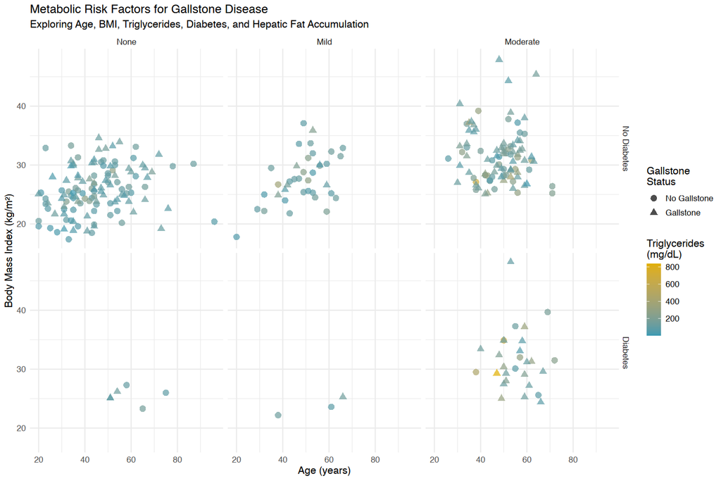

```r
# REVISED: Added comments explaining visualization design choices

# Set plot dimensions for better readability
options(repr.plot.width = 12, repr.plot.height = 8)

# Create multi-variable exploratory plot
exploratory_plot <- gallstone %>%
  # Filter to hepatic fat levels with sufficient data
  filter(hepatic_fat %in% c("0", "1", "2")) %>%
  mutate(
    # Create readable labels for categorical variables
    gallstone_status = factor(gallstone, labels = c("No Gallstone", "Gallstone")),
    diabetes_status = factor(diabetes, labels = c("No Diabetes", "Diabetes")),
    hfa_level = factor(hepatic_fat,
                       levels = c("0", "1", "2"),
                       labels = c("None", "Mild", "Moderate"))
  ) %>%
  # Map variables to visual aesthetics
  ggplot(aes(x = age,
             y = bmi,
             color = triglycerides,
             shape = gallstone_status)) +
  geom_point(size = 3, alpha = 0.7) +
  scale_color_gradient(low = "#3B9AB2", high = "#E1AF00",
                       name = "Triglycerides\n(mg/dL)") +
  # Different shapes for gallstone status
  scale_shape_manual(values = c(16, 17), name = "Gallstone\nStatus") +
  # Facet by diabetes and hepatic fat levels
  facet_grid(diabetes_status ~ hfa_level) +
  labs(
    title = "Metabolic Risk Factors for Gallstone Disease",
    subtitle = "Exploring Age, BMI, Triglycerides, Diabetes, and Hepatic Fat Accumulation",
    x = "Age (years)",
    y = "Body Mass Index (kg/m²)"
  ) +
  theme_minimal() +
  theme(
    text = element_text(size = 12),
    plot.title = element_text(face = "bold", size = 14),
    strip.text = element_text(face = "bold")
  )


exploratory_plot
```

**Variable Selection for Visualization:**

From the 12 variables in our cleaned dataset, I selected 5 variables for this visualization: age, BMI, triglycerides, diabetes status, and hepatic fat accumulation. I chose these because they represent different aspects of metabolic health body composition (BMI), blood lipids (triglycerides), blood sugar regulation (diabetes), and liver fat (hepatic fat) while keeping the plot interpretable. I filtered hepatic fat to only show levels 0, 1, and 2 because levels 3 and 4 had very few observations (27 total out of 319), which would create mostly empty panels.

### Visualization Interpretation

**Why this plot is relevant:**

This visualization explores five variables at once by using position (age, BMI), color (triglycerides), shape (gallstone status), and facets (diabetes, hepatic fat). Faceting by diabetes and hepatic fat lets me see whether gallstone patterns differ across these metabolic conditions. This multi-variable view is useful because gallstone disease likely involves multiple risk factors rather than just one.

**Results obtained:**

The plot shows that gallstone patients (triangles) and non-gallstone patients (circles) overlap considerably in age and BMI across all six panels. Most patients have low-to-moderate triglyceride levels (blue/teal colors), with only a few showing high levels (yellow colors). The top row (No Diabetes) has far more patients than the bottom row (Diabetes), and the Moderate hepatic fat panel appears to have the most observations overall. Among diabetes patients, gallstone cases seem to cluster more in the Moderate hepatic fat panel at higher BMI values. Overall, no single variable clearly separates gallstone from non-gallstone patients, suggesting that multiple factors may be involved.

**What I learned:**

Three things stand out from this visualization. First, the overlap between gallstone and non-gallstone patients across age and BMI suggests that these factors alone won't predict gallstone disease well. Second, the Moderate hepatic fat panel contains the most data and shows a noticeable concentration of gallstone cases, especially among diabetes patients. Third, most patients have relatively low triglyceride levels regardless of gallstone status, so extremely high triglycerides don't seem necessary for gallstone formation in this dataset. These patterns suggest I'll need a multivariable model to understand how these factors work together.

## Section 4: Method and Plan

**Proposed Method:**

I will use **logistic regression** to model the binary response variable (gallstone presence/absence) as a function of the metabolic and demographic predictors.

**Why is this method appropriate?**

Logistic regression is appropriate because our response variable is binary (gallstone present or absent), and we want to understand how each predictor is associated with the log-odds of gallstone disease while controlling for other variables.

**Assumptions required:**

1. The log-odds of the outcome have a linear relationship with the continuous predictors
2. Observations are independent (each patient is measured once)
3. No perfect multicollinearity among predictors (though some correlation is acceptable)

**Limitations and weaknesses:**

1. Logistic regression assumes linear log-odds relationships, which may not capture complex non-linear patterns
2. The model is sensitive to outliers and influential observations
3. It may miss important interactions between predictors unless explicitly specified
4. With 11 predictors and 319 observations, we have adequate sample size (~29 observations per predictor), but adding many interaction terms could lead to overfitting

## Section 5: Computational Code and Output

I will fit a logistic regression model with gallstone status as the response and all selected metabolic/demographic variables as predictors. I will visualize the results using a coefficient plot showing odds ratios with confidence intervals.

```r
# REVISED: Data cleaning to fix convergence warnings and fit model

# 1. Fix: Collapse rare Hepatic Fat levels (3 & 4) into Level 2
# This prevents the "fitted probabilities 0 or 1" warnings seen in the previous draft
gallstone_clean <- gallstone %>%
  mutate(
    hepatic_fat_fixed = case_when(
      as.numeric(as.character(hepatic_fat)) >= 2 ~ "2+", # Group Levels 2, 3, 4 together
      TRUE ~ as.character(hepatic_fat)
    ),
    hepatic_fat_fixed = as.factor(hepatic_fat_fixed)
  )

# 2. Fit logistic regression model using the stable "hepatic_fat_fixed" variable
gallstone_model <- glm(
  gallstone ~ age + gender + bmi + glucose + diabetes +
              cholesterol + ldl + hdl + triglycerides +
              visceral_fat + hepatic_fat_fixed,
  data = gallstone_clean,
  family = binomial(link = "logit")
)

# Display model summary
summary(gallstone_model)

# 3. Check for multicollinearity using VIF
cat("\n=== VARIANCE INFLATION FACTORS (VIF) ===\n")
cat("(VIF > 5 indicates problematic multicollinearity)\n\n")
vif_values <- vif(gallstone_model)
print(round(vif_values, 2))

# 4. Extract tidy results with odds ratios
model_results <- tidy(gallstone_model, conf.int = TRUE, exponentiate = TRUE)

# Display significant predictors
cat("\n=== SIGNIFICANT PREDICTORS (p < 0.05) ===\n\n")
sig_predictors <- model_results %>%
  filter(p.value < 0.05, term != "(Intercept)") %>%
  select(term, estimate, conf.low, conf.high, p.value) %>%
  mutate(across(where(is.numeric), ~round(., 3)))
print(sig_predictors)
```

```
Call:
glm(formula = gallstone ~ age + gender + bmi + glucose + diabetes +
    cholesterol + ldl + hdl + triglycerides + visceral_fat +
    hepatic_fat_fixed, family = binomial(link = "logit"), data = gallstone_clean)

Coefficients:
                     Estimate Std. Error z value Pr(>|z|)
(Intercept)          0.109949   1.273710   0.086  0.93121
age                 -0.004110   0.011112  -0.370  0.71146
gender1              0.667807   0.302406   2.208  0.02722 *
bmi                 -0.078170   0.051741  -1.511  0.13084
glucose             -0.003775   0.003778  -0.999  0.31769
diabetes1            0.904727   0.446810   2.025  0.04288 *
cholesterol          0.011969   0.008332   1.437  0.15084
ldl                 -0.013546   0.008741  -1.550  0.12120
hdl                  0.011037   0.014709   0.750  0.45303
triglycerides       -0.002710   0.002046  -1.325  0.18529
visceral_fat         0.105671   0.048934   2.159  0.03081 *
hepatic_fat_fixed1  -1.351055   0.450261  -3.001  0.00269 **
hepatic_fat_fixed2+  0.616959   0.335464   1.839  0.06590 .
---
Signif. codes:  0 ‘***’ 0.001 ‘**’ 0.01 ‘*’ 0.05 ‘.’ 0.1 ‘ ’ 1

(Dispersion parameter for binomial family taken to be 1)

    Null deviance: 442.2  on 318  degrees of freedom
Residual deviance: 391.6  on 306  degrees of freedom
AIC: 417.6

Number of Fisher Scoring iterations: 4
```

```
=== VARIANCE INFLATION FACTORS (VIF) ===
(VIF > 5 indicates problematic multicollinearity)

                  GVIF Df GVIF^(1/(2*Df))
age               1.22  1            1.11
gender            1.56  1            1.25
bmi               4.84  1            2.20
glucose           1.58  1            1.26
diabetes          1.51  1            1.23
cholesterol       9.96  1            3.16
ldl               7.62  1            2.76
hdl               2.35  1            1.53
triglycerides     2.85  1            1.69
visceral_fat      4.15  1            2.04
hepatic_fat_fixed 1.82  2            1.16

=== SIGNIFICANT PREDICTORS (p < 0.05) ===

# A tibble: 4 × 5
  term               estimate conf.low conf.high p.value
  <chr>                 <dbl>    <dbl>     <dbl>   <dbl>
1 gender1               1.95     1.08      3.54    0.027
2 diabetes1             2.47     1.06      6.15    0.043
3 visceral_fat          1.11     1.01      1.23    0.031
4 hepatic_fat_fixed1    0.259    0.101     0.602   0.003
```

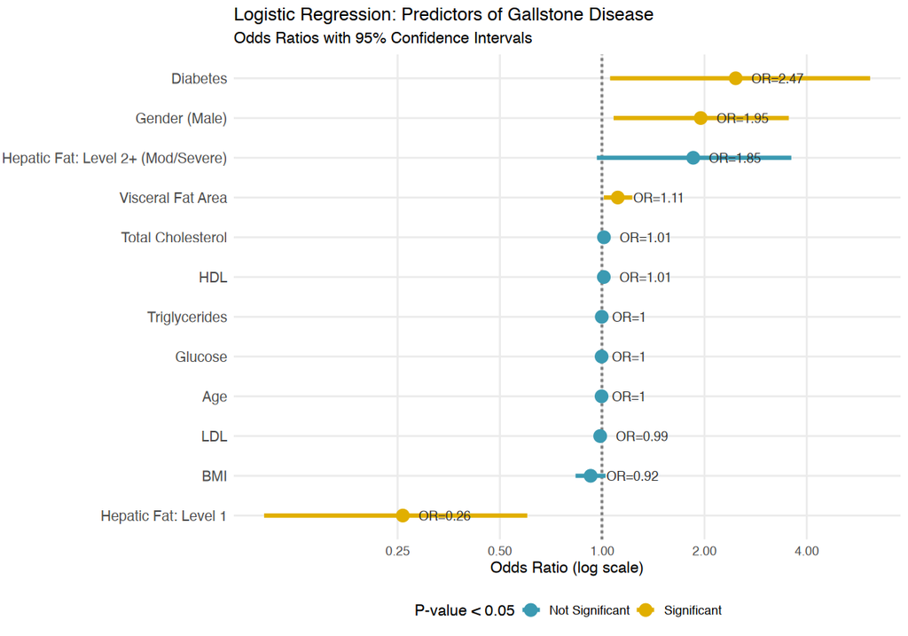

```r
# REVISED: Create professional coefficient plot

# Set dimensions
options(repr.plot.width = 10, repr.plot.height = 7)

# Prepare data for plotting
plot_data <- model_results %>%
  filter(term != "(Intercept)") %>%
  mutate(
    term_clean = case_when(
      term == "age" ~ "Age",
      term == "gender1" ~ "Gender (Male)",
      term == "bmi" ~ "BMI",
      term == "glucose" ~ "Glucose",
      term == "diabetes1" ~ "Diabetes",
      term == "cholesterol" ~ "Total Cholesterol",
      term == "ldl" ~ "LDL",
      term == "hdl" ~ "HDL",
      term == "triglycerides" ~ "Triglycerides",
      term == "visceral_fat" ~ "Visceral Fat Area",
      term == "hepatic_fat_fixed1" ~ "Hepatic Fat: Level 1",
      term == "hepatic_fat_fixed2+" ~ "Hepatic Fat: Level 2+ (Mod/Severe)",
      TRUE ~ term
    ),
    significant = ifelse(p.value < 0.05, "Significant", "Not Significant"),
    or_label = paste0("OR=", round(estimate, 2))
  )

# Create coefficient plot
coefficient_plot <- ggplot(plot_data, aes(y = reorder(term_clean, estimate))) +
  geom_vline(xintercept = 1, linetype = "dashed", color = "gray50", linewidth = 0.8) +
  geom_errorbar(aes(xmin = conf.low, xmax = conf.high, color = significant),
                width = 0, linewidth = 1.2) +
  geom_point(aes(x = estimate, color = significant), size = 4) +
  geom_text(aes(x = estimate, label = or_label),
            hjust = -0.3, size = 3.5, color = "gray20") +
  scale_color_manual(
    values = c("Significant" = "#E1AF00", "Not Significant" = "#3B9AB2"),
    name = "P-value < 0.05"
  ) +
  scale_x_log10(breaks = c(0.25, 0.5, 1, 2, 4)) +
  labs(
    title = "Logistic Regression: Predictors of Gallstone Disease",
    subtitle = "Odds Ratios with 95% Confidence Intervals",
    x = "Odds Ratio (log scale)",
    y = NULL
  ) +
  theme_minimal(base_size = 12) +
  theme(
    plot.title = element_text(face = "bold", size = 14),
    axis.text.y = element_text(size = 11),
    legend.position = "bottom",
    panel.grid.minor = element_blank()
  )

coefficient_plot
```

**Interpretation:**

The logistic regression identifies three statistically significant risk factors ($p < 0.05$): Male gender (OR=1.95), Diabetes (OR=2.47), and Visceral Fat Area (OR=1.11 per unit). Interestingly, Hepatic Fat Level 1 appears significantly protective compared to Level 0 ($p=0.003$), while Moderate/Severe Hepatic Fat (Level 2+) shows a strong positive association (OR=1.85) that approaches but does not quite reach statistical significance ($p=0.066$) in this adjusted model. The VIF analysis confirms high multicollinearity among lipid markers (Cholesterol VIF=9.96, LDL VIF=7.62), explaining why these individual lipid variables appear non-significant despite their biological relevance.